## Read me file

In order to predict the electricity consumption for every month, where future month cannot be taken into account in the prediction of current month, dynamic dataset had been used. I have used generalised boosted regression model for the prediction.

Only three packages had been used for the prediction,

*dplyr Data Manipulation* gbm Model *corrplot Correlation Matrix

### Read the Dataset

The dataset has been read using the following command in R.

```r
data<-read.csv("train.csv",stringsAsFactors = FALSE)
test<-read.csv("test.csv",stringsAsFactors = FALSE)
sample<-read.csv("sample_submission.csv",stringsAsFactors = FALSE)
```

#### Examine the dataset

Let us check the correlation of the variables on the independent variable, in this context it is electricity consumption.

Before, building a correlation matrix, we need to examine the class of each variable by the following code,

```r
str(data)
```

Upon careful examination, we can see that var2 (anonymous variable) is in character of thee levels A, B, C Now, in order to establish the correalation of this variable with other variable, it has to convert itself into numbers. With the following code, the elements of anonymous variable var2 can be converted into numeric values 1,2,3 with the match function.

```r
myLetters<-toupper(letters[1:26])
data$var2<-match(data$var2, myLetters)
```

Now, correlation matrix can be computed on the dataset.

##### Select the variables for computation of correlation matrix

```r
data_cor<-data[,c(3,4,5,6,7,8)]
```

Computation of correlation matrix

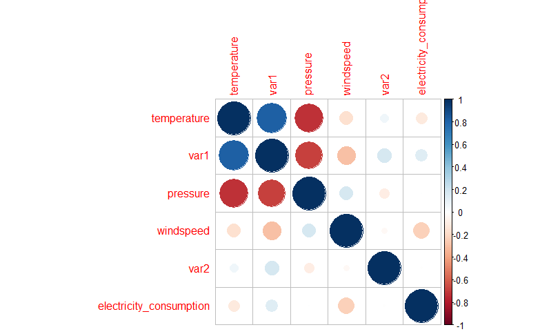

Correlation Matrix

```r
cor_mat<-cor(data_cor)
corrplot(cor_mat)
```

Positive correlations are displayed in blue and negative correlations in red color. Color intensity and the size of the circle are proportional to the correlation coefficients. In the right side of the correlogram, the legend color shows the correlation coefficients and the corresponding colors.

##### Selection of variables for Model building

After careful examination, the variable var2 can be dropped as its correlation value to the dependent varaiable is -0.0069

#### Date Format

##### Split the date into month into year and month for both train and test data file

```r
data$datetime<- as.Date(data$datetime)
data$year<- as.numeric(format(data$datetime, format = "%Y"))
data$mon<-as.numeric(format(data$datetime,format = "%m"))

## Format test data file
test$datetime<- as.Date(test$datetime, "%d-%m-%Y")
test$year<- as.numeric(format(test$datetime, format = "%Y"))
test$mon<-as.numeric(format(test$datetime,format = "%m"))
```

##### Create the function to count the number of rows in dataset as the dataset unfold with changing months and years

I have used the dataset in such a way that dataset unfolds with respective changing month and year. For that, I have build a function using dplyr package in the following manner,

```r
Run_count=function(Month,Year){
  ## Dynamic Dataset
  data1=data%>% filter(mon<=Month & year<=Year)
  return(nrow(data1))
}

Run_count(12,2017)
Output: 26496

Run_count(6,2016)
Output: 9936
```

Its clear, the above function is working properly. This will be used in the final model.

#### Build the user defined function for Training Model

In this section “newdata” frame is created for each month and year for the prediction of values from 24th to 31st or 30th of the current month. For prediction, generalised regression boosted model had been used.

```r
Run_pred=function(Month,Year){
  newdata=test%>%select(ID,temperature,var1,pressure,windspeed,year,mon)%>%filter(mon==Month & year== Year)
  ## Dynamic Dataset
  data1=data%>% filter(mon<=Month & year<=Year)

gbmM1<-gbm(electricity_consumption~temperature+var1+pressure+windspeed,
             distribution="gaussian",interaction.depth=3, n.cores=detectCores()/2,
             n.trees = 2500,shrinkage = 0.001, data = data1 )
  gbmTrainPredictions <- predict.gbm(object=gbmM1, newdata=newdata, n.trees=2500,
                                     type="response")
  sample<-data.frame(paste(newdata$ID,gbmTrainPredictions))
  return(sample)
}
```

#### User defined function for each month and year to compute the prediction values

```r
Pred_Year=function(x){y<-NULL;
  for(j in unique(7:12)){t<-Run_pred(j,x)
  y<-rbind(y,t)}
  return(y)
}

Pred_2013<-Pred_Year(2013)
```

##### General UDF for all the years

```r
Pred_Year=function(x){y<-NULL;
for(j in unique(1:12))
{t<-Run_Pred(j,x)
  y<-rbind(y,t)}
return(y)
}

Pred_2014<-Pred_Year(2014)
Pred_2015<-Pred_Year(2015)
Pred_2016<-Pred_Year(2016)
Pred_2017<-Pred_Year(2017)
```

#### Combine the data in one file

So far all the prediction values has been calculated by the above function and store under respective years with confined dataset as mentioned in the problem statement. Now its time to combine all the data together into one file, sample_submission.

##### Rbind

```r
Sample_Submission<-data.frame(rbind(Pred_2013,Pred_2014,Pred_2015,Pred_2016,Pred_2017))

sample_submission<-write.csv(Sample_Submission,"sample_submission.csv")
```